# Quick and basic example of working with git

Here is the workflow I attempted to demonstrate during the Git Rganized workshop.

### 1. Create a repository on GitHub.

#### i) Log in to [GitHub](https://github.com/login).

#### ii) Create a **new repository**.

Click **New repository** from the **+** dropdown menu on the top-right of the welcome screen next to your profile pic.

[figure not shown]

Fill in the fields of the **Create a new repository** page.

Choose whether you want your repos to be *public* or *private* (you can make private repositories public later). I recommend you click **Initialize this repository with a README** so you won’t forget to create a README later. I also recommend you add a **.gitignore** for the scripting language that you use. **Add a license** to allow other people to use your work. When you’re done, click the green **Create repository** button at the bottom of the screen.

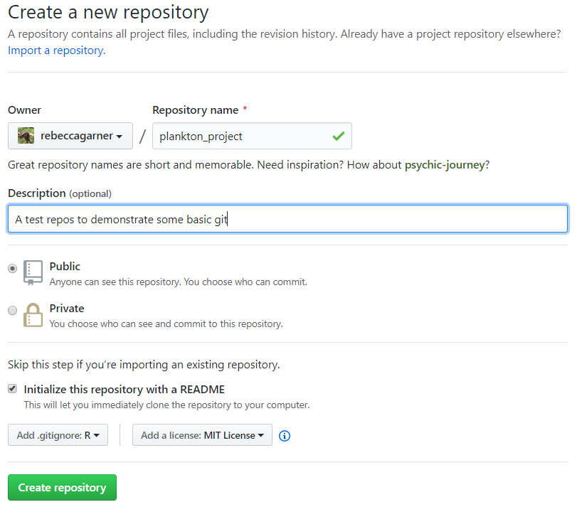

### 2. Clone your repository to your computer.

Your repository now exists as a *remote* repository on GitHub (remote = internet repository version that can be made accessible to other people). To be able to work on your repository from your local computer, you need to *clone* it to a location on your computer. Click on the green **Clone or download** button, highlight the URL in the box, and *copy* it.

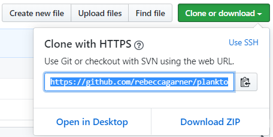

Open **Terminal** (on Mac) or **Git Bash** or **Command Prompt** (on Windows). Navigate to the folder where you want to store your repository. Use the command `git clone REPOSITORY_URL` to clone your repository (*paste* your copied URL instead of `REPOSITORY_URL`). In this example, I am cloning my plankton_project repository into my Documents folder.

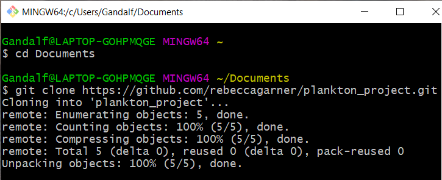

Optional: you can open the folder containing your cloned repository to *see* that it’s there.

[figure not shown]

`cd` into your repository and list all the files it contains.

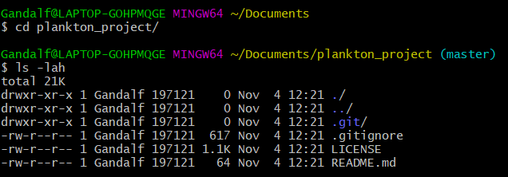

You’ll notice that the repository contains a folder named **.git/**. This **.git** folder contains the git version tracking information (so never delete the **.git** folder!)

#### A very short list of useful UNIX commands to help you navigate on the command line.

- `cd` changes the directory (directory = folder). `cd ..` moves up one directory. `cd /` moves up to the root directory.
- `pwd` tells you what directory you are currently in.
- `ls` lists the files in the current directory.`ls -lah` (which is `ls` with the argument `-lah`) lists all files including files with extensions starting with “.” (e.g. .git or .gitignore).
- `touch FILE.EXTENSION` creates a file. E.g. I want to create an R script named *import_data*: `touch import_data.R`

Note: UNIX commands have help information accessible by adding the argument `--help` after the command. Also note: UNIX commands are case-sensitive.

### 3. Track changes to your repository.

First, you’ll need to make changes to your repository. By changes, I mean you can create one or more files and/or edit files. You can create files directly from the command line (`touch FILE.EXTENSION`) or drag and drop files into the repository folder from someplace else on your computer. You can similarly edit files like you would any other file elsewhere on your computer, i.e. by opening it and making edits in R, MS Office Suite, a text editor, etc.

Here’s an example where I am creating an R script named *import_data* and storing it in a subdirectory named *scripts*.

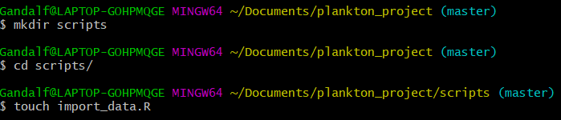

And here is the newly created file in its newly created subfolder.

[figure not shown]

[figure not shown]

But we can go ahead and make an edit. In this example, I’ve added a small comment to show the 1st edit.

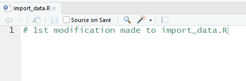

Time to track changes to this file! Open **Terminal**/**Git Bash**/**Command Prompt**, and navigate to your repository (make sure you are cd’ed *INTO* your repository!).

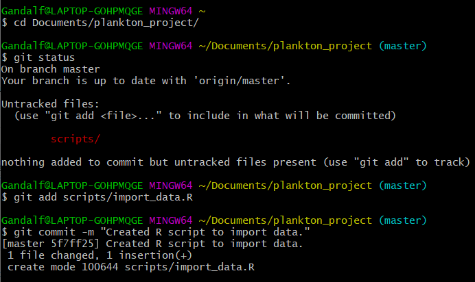

What I’ve done here is: 1) checked `git status` which let me know the version tracking status of files in the repository; 2) added files to the staging area using `git add MODIFIED_FILE`; 3) committed changes to the files I added to the staging area using `git commit -m "COMMIT_MESSAGE"`, where the commit message describes the changes I’ve made.

Time to push your commit to your *remote* (GitHub) repository. The command `git push origin master` pushed all your commits since your last push on a particular branch you are working on. In this case, you’ve been working on the *master* branch. The `master` part of the command `git push origin master` refers to the branch you are on, whereas `origin` refers to the remote GitHub repository.

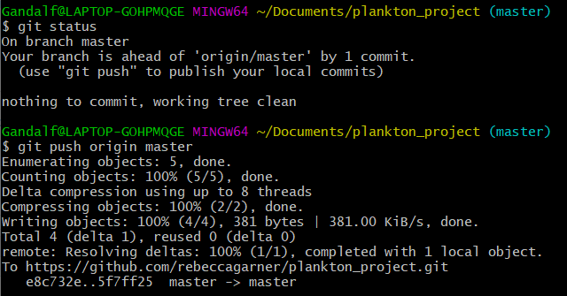

Go to the GitHub page of your repository (Under the **Repositories** tab on your profile page > Click on the repository name).

[figure not shown]

Notice that it shows you now have *2 commits*.

[figure not shown]

Click on the link in *2 commits*. It contains details of your commits (this is version history!), with specific details about file additions/deletions which represent the changes you committed.

[figure not shown]

### Keep making changes and tracking them!

You can go back to your local repository to create and modify files. Repeat the `git add` and `git commit -m "COMMIT_MESSAGE"` workflow to keep a version history of your files. **Local commits are important!** They snapshot the version of your repository at a given time. So, **commit often** to give your future self access to incremental versions of your work. You’ll get a feel for how often you should `git push`.

#### Stay tuned: I’ll try to write a short guide to working with branches for collaboration in the near future. Thanks for following along, and don’t hesitate to reach out: rebecca.garner@mail.concordia.ca